# Risk Factor Analysis

## Outcome Variable

**Outcome Variable:** sstunted

## Predictor Variables

**Intervention Variable:** hhwealth_quart

**Adjustment Set:**

- arm
- sex
- W_mage
- meducyrs
- feducyrs
- W_gagebrth
- W_birthwt
- W_birthlen
- W_nchldlt5
- W_parity
- delta_W_mage
- delta_meducyrs
- delta_feducyrs
- delta_W_gagebrth
- delta_W_birthwt
- delta_W_birthlen
- delta_W_nchldlt5
- delta_W_parity

## Stratifying Variables

The analysis was stratified on these variable(s):

- agecat
- studyid
- country

## Data Summary

| agecat | studyid | country | hhwealth_quart | sstunted | n_cell | n |
| --- | --- | --- | --- | --- | --- | --- |
| Birth | CMC-V-BCS-2002 | INDIA | Wealth Q4 | 0 | 31 | 92 |
| Birth | CMC-V-BCS-2002 | INDIA | Wealth Q4 | 1 | 1 | 92 |
| Birth | CMC-V-BCS-2002 | INDIA | Wealth Q1 | 0 | 15 | 92 |
| Birth | CMC-V-BCS-2002 | INDIA | Wealth Q1 | 1 | 0 | 92 |
| Birth | CMC-V-BCS-2002 | INDIA | Wealth Q2 | 0 | 19 | 92 |
| Birth | CMC-V-BCS-2002 | INDIA | Wealth Q2 | 1 | 1 | 92 |
| Birth | CMC-V-BCS-2002 | INDIA | Wealth Q3 | 0 | 23 | 92 |
| Birth | CMC-V-BCS-2002 | INDIA | Wealth Q3 | 1 | 2 | 92 |
| Birth | COHORTS | GUATEMALA | Wealth Q4 | 0 | 291 | 816 |
| Birth | COHORTS | GUATEMALA | Wealth Q4 | 1 | 2 | 816 |
| Birth | COHORTS | GUATEMALA | Wealth Q1 | 0 | 157 | 816 |
| Birth | COHORTS | GUATEMALA | Wealth Q1 | 1 | 0 | 816 |
| Birth | COHORTS | GUATEMALA | Wealth Q2 | 0 | 158 | 816 |
| Birth | COHORTS | GUATEMALA | Wealth Q2 | 1 | 3 | 816 |
| Birth | COHORTS | GUATEMALA | Wealth Q3 | 0 | 201 | 816 |
| Birth | COHORTS | GUATEMALA | Wealth Q3 | 1 | 4 | 816 |
| Birth | COHORTS | PHILIPPINES | Wealth Q4 | 0 | 835 | 3049 |
| Birth | COHORTS | PHILIPPINES | Wealth Q4 | 1 | 7 | 3049 |
| Birth | COHORTS | PHILIPPINES | Wealth Q1 | 0 | 675 | 3049 |
| Birth | COHORTS | PHILIPPINES | Wealth Q1 | 1 | 12 | 3049 |
| Birth | COHORTS | PHILIPPINES | Wealth Q2 | 0 | 524 | 3049 |
| Birth | COHORTS | PHILIPPINES | Wealth Q2 | 1 | 14 | 3049 |
| Birth | COHORTS | PHILIPPINES | Wealth Q3 | 0 | 969 | 3049 |
| Birth | COHORTS | PHILIPPINES | Wealth Q3 | 1 | 13 | 3049 |
| Birth | CONTENT | PERU | Wealth Q4 | 0 | 0 | 2 |
| Birth | CONTENT | PERU | Wealth Q4 | 1 | 0 | 2 |
| Birth | CONTENT | PERU | Wealth Q1 | 0 | 0 | 2 |
| Birth | CONTENT | PERU | Wealth Q1 | 1 | 0 | 2 |
| Birth | CONTENT | PERU | Wealth Q2 | 0 | 1 | 2 |
| Birth | CONTENT | PERU | Wealth Q2 | 1 | 0 | 2 |

[output cut: 386 more lines]

The following strata were considered:

- agecat: 24 months, studyid: CMC-V-BCS-2002, country: INDIA
- agecat: 24 months, studyid: COHORTS, country: GUATEMALA
- agecat: 24 months, studyid: COHORTS, country: PHILIPPINES
- agecat: 24 months, studyid: CONTENT, country: PERU
- agecat: 24 months, studyid: GMS-Nepal, country: NEPAL
- agecat: 24 months, studyid: IRC, country: INDIA
- agecat: 24 months, studyid: JiVitA-3, country: BANGLADESH
- agecat: 24 months, studyid: JiVitA-4, country: BANGLADESH
- agecat: 24 months, studyid: LCNI-5, country: MALAWI
- agecat: 24 months, studyid: MAL-ED, country: BANGLADESH
- agecat: 24 months, studyid: MAL-ED, country: BRAZIL
- agecat: 24 months, studyid: MAL-ED, country: INDIA
- agecat: 24 months, studyid: MAL-ED, country: NEPAL
- agecat: 24 months, studyid: MAL-ED, country: PERU
- agecat: 24 months, studyid: MAL-ED, country: SOUTH AFRICA
- agecat: 24 months, studyid: MAL-ED, country: TANZANIA, UNITED REPUBLIC OF
- agecat: 24 months, studyid: PROVIDE, country: BANGLADESH
- agecat: 24 months, studyid: TanzaniaChild2, country: TANZANIA, UNITED REPUBLIC OF
- agecat: 6 months, studyid: CMC-V-BCS-2002, country: INDIA
- agecat: 6 months, studyid: COHORTS, country: GUATEMALA
- agecat: 6 months, studyid: COHORTS, country: PHILIPPINES
- agecat: 6 months, studyid: CONTENT, country: PERU
- agecat: 6 months, studyid: GMS-Nepal, country: NEPAL
- agecat: 6 months, studyid: IRC, country: INDIA
- agecat: 6 months, studyid: JiVitA-3, country: BANGLADESH
- agecat: 6 months, studyid: JiVitA-4, country: BANGLADESH
- agecat: 6 months, studyid: LCNI-5, country: MALAWI
- agecat: 6 months, studyid: MAL-ED, country: BANGLADESH
- agecat: 6 months, studyid: MAL-ED, country: BRAZIL
- agecat: 6 months, studyid: MAL-ED, country: INDIA
- agecat: 6 months, studyid: MAL-ED, country: NEPAL
- agecat: 6 months, studyid: MAL-ED, country: PERU
- agecat: 6 months, studyid: MAL-ED, country: SOUTH AFRICA
- agecat: 6 months, studyid: MAL-ED, country: TANZANIA, UNITED REPUBLIC OF
- agecat: 6 months, studyid: PROVIDE, country: BANGLADESH
- agecat: 6 months, studyid: TanzaniaChild2, country: TANZANIA, UNITED REPUBLIC OF
- agecat: Birth, studyid: CMC-V-BCS-2002, country: INDIA
- agecat: Birth, studyid: COHORTS, country: GUATEMALA
- agecat: Birth, studyid: COHORTS, country: PHILIPPINES
- agecat: Birth, studyid: CONTENT, country: PERU
- agecat: Birth, studyid: GMS-Nepal, country: NEPAL
- agecat: Birth, studyid: IRC, country: INDIA
- agecat: Birth, studyid: JiVitA-3, country: BANGLADESH
- agecat: Birth, studyid: JiVitA-4, country: BANGLADESH
- agecat: Birth, studyid: MAL-ED, country: BANGLADESH
- agecat: Birth, studyid: MAL-ED, country: BRAZIL
- agecat: Birth, studyid: MAL-ED, country: INDIA
- agecat: Birth, studyid: MAL-ED, country: NEPAL
- agecat: Birth, studyid: MAL-ED, country: PERU
- agecat: Birth, studyid: MAL-ED, country: SOUTH AFRICA
- agecat: Birth, studyid: MAL-ED, country: TANZANIA, UNITED REPUBLIC OF
- agecat: Birth, studyid: PROVIDE, country: BANGLADESH

### Dropped Strata

Some strata were dropped due to rare outcomes:

- agecat: Birth, studyid: CMC-V-BCS-2002, country: INDIA
- agecat: Birth, studyid: COHORTS, country: GUATEMALA
- agecat: Birth, studyid: CONTENT, country: PERU
- agecat: Birth, studyid: IRC, country: INDIA
- agecat: Birth, studyid: MAL-ED, country: BANGLADESH
- agecat: Birth, studyid: MAL-ED, country: BRAZIL
- agecat: Birth, studyid: MAL-ED, country: INDIA
- agecat: Birth, studyid: MAL-ED, country: NEPAL
- agecat: Birth, studyid: MAL-ED, country: PERU
- agecat: Birth, studyid: MAL-ED, country: SOUTH AFRICA
- agecat: Birth, studyid: MAL-ED, country: TANZANIA, UNITED REPUBLIC OF
- agecat: Birth, studyid: PROVIDE, country: BANGLADESH
- agecat: 6 months, studyid: CMC-V-BCS-2002, country: INDIA
- agecat: 6 months, studyid: CONTENT, country: PERU
- agecat: 6 months, studyid: GMS-Nepal, country: NEPAL
- agecat: 6 months, studyid: IRC, country: INDIA
- agecat: 6 months, studyid: MAL-ED, country: BANGLADESH
- agecat: 6 months, studyid: MAL-ED, country: BRAZIL
- agecat: 6 months, studyid: MAL-ED, country: INDIA
- agecat: 6 months, studyid: MAL-ED, country: NEPAL
- agecat: 6 months, studyid: MAL-ED, country: PERU
- agecat: 6 months, studyid: MAL-ED, country: SOUTH AFRICA
- agecat: 6 months, studyid: MAL-ED, country: TANZANIA, UNITED REPUBLIC OF
- agecat: 6 months, studyid: PROVIDE, country: BANGLADESH
- agecat: 6 months, studyid: TanzaniaChild2, country: TANZANIA, UNITED REPUBLIC OF
- agecat: 24 months, studyid: CONTENT, country: PERU
- agecat: 24 months, studyid: MAL-ED, country: BANGLADESH
- agecat: 24 months, studyid: MAL-ED, country: BRAZIL
- agecat: 24 months, studyid: MAL-ED, country: NEPAL
- agecat: 24 months, studyid: MAL-ED, country: PERU
- agecat: 24 months, studyid: MAL-ED, country: SOUTH AFRICA
- agecat: 24 months, studyid: TanzaniaChild2, country: TANZANIA, UNITED REPUBLIC OF

## Methods Detail

We’re interested in the causal parameters $E[Y_a]$ for all values of $a \in \mathcal{A}$. These parameters represent the mean outcome if, possibly contrary to fact, we intervened to set all units to have $A=a$. Under the randomization and positivity assumptions, these are identified by the statistical parameters $\psi_a=E_W[E_{Y|A,W}(Y|A=a,W)]$. In addition, we’re interested in the mean of $Y$, $E[Y]$ under no intervention (the observed mean). We will estimate these parameters by using SuperLearner to fit the relevant likelihood factors – $E_{Y|A,W}(Y|A=a,W)$ and $p(A=a|W)$, and then updating our likelihood fit using a joint TMLE.

For unadjusted analyses ($W=\{\}$), initial likelihoods were estimated using Lrnr_glm to estimate the simple $E(Y|A)$ and Lrnr_mean to estimate $p(A)$. For adjusted analyses, a small library containing Lrnr_glmnet, Lrnr_xgboost, and Lrnr_mean was used.

Having estimated these parameters, we will then use the delta method to estimate relative risks and attributable risks relative to a prespecified baseline level of $A$.

# Results Detail

## Results Plots

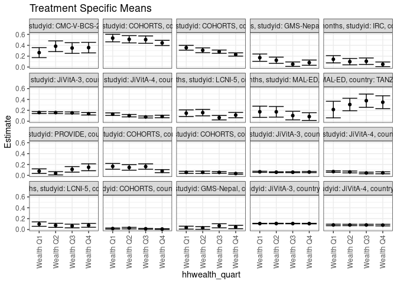

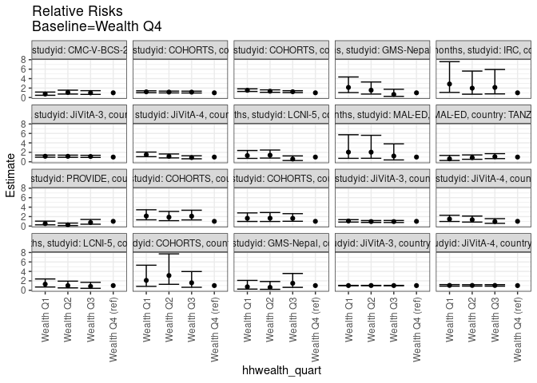

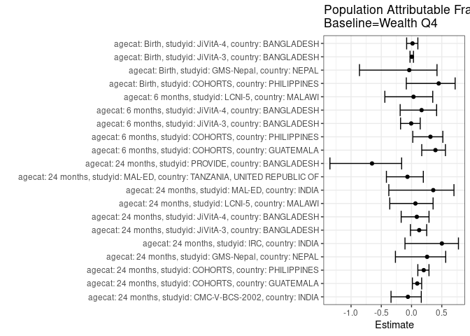

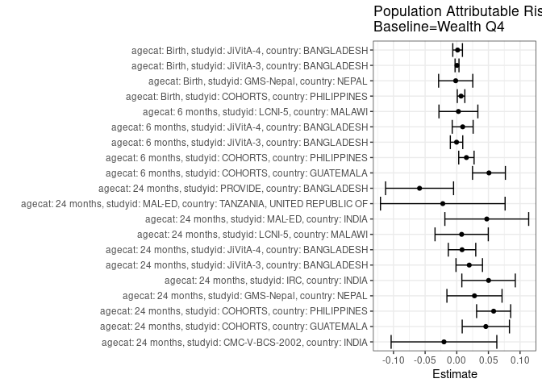

## Results Table

### Parameter: TSM

| agecat | studyid | country | intervention_level | baseline_level | estimate | ci_lower | ci_upper |
| --- | --- | --- | --- | --- | --- | --- | --- |
| Birth | COHORTS | PHILIPPINES | Wealth Q4 | NA | 0.0083135 | 0.0021795 | 0.0144475 |
| Birth | COHORTS | PHILIPPINES | Wealth Q1 | NA | 0.0174672 | 0.0076695 | 0.0272650 |
| Birth | COHORTS | PHILIPPINES | Wealth Q2 | NA | 0.0260223 | 0.0125676 | 0.0394771 |
| Birth | COHORTS | PHILIPPINES | Wealth Q3 | NA | 0.0132383 | 0.0060886 | 0.0203880 |
| Birth | GMS-Nepal | NEPAL | Wealth Q4 | NA | 0.0462428 | 0.0149259 | 0.0775596 |
| Birth | GMS-Nepal | NEPAL | Wealth Q1 | NA | 0.0342857 | 0.0073069 | 0.0612645 |
| Birth | GMS-Nepal | NEPAL | Wealth Q2 | NA | 0.0287356 | 0.0038949 | 0.0535764 |
| Birth | GMS-Nepal | NEPAL | Wealth Q3 | NA | 0.0689655 | 0.0312878 | 0.1066432 |
| Birth | JiVitA-3 | BANGLADESH | Wealth Q4 | NA | 0.1087228 | 0.1031526 | 0.1142930 |
| Birth | JiVitA-3 | BANGLADESH | Wealth Q1 | NA | 0.1093378 | 0.1044949 | 0.1141806 |
| Birth | JiVitA-3 | BANGLADESH | Wealth Q2 | NA | 0.1101195 | 0.1052407 | 0.1149983 |
| Birth | JiVitA-3 | BANGLADESH | Wealth Q3 | NA | 0.1093821 | 0.1045425 | 0.1142216 |
| Birth | JiVitA-4 | BANGLADESH | Wealth Q4 | NA | 0.0812958 | 0.0668614 | 0.0957302 |
| Birth | JiVitA-4 | BANGLADESH | Wealth Q1 | NA | 0.0842154 | 0.0702584 | 0.0981723 |
| Birth | JiVitA-4 | BANGLADESH | Wealth Q2 | NA | 0.0839366 | 0.0710205 | 0.0968527 |
| Birth | JiVitA-4 | BANGLADESH | Wealth Q3 | NA | 0.0835252 | 0.0703343 | 0.0967161 |
| 6 months | COHORTS | GUATEMALA | Wealth Q4 | NA | 0.0778085 | 0.0494659 | 0.1061510 |
| 6 months | COHORTS | GUATEMALA | Wealth Q1 | NA | 0.1655345 | 0.1124962 | 0.2185728 |
| 6 months | COHORTS | GUATEMALA | Wealth Q2 | NA | 0.1458320 | 0.0953551 | 0.1963090 |
| 6 months | COHORTS | GUATEMALA | Wealth Q3 | NA | 0.1620686 | 0.1125964 | 0.2115408 |
| 6 months | COHORTS | PHILIPPINES | Wealth Q4 | NA | 0.0335174 | 0.0204157 | 0.0466191 |
| 6 months | COHORTS | PHILIPPINES | Wealth Q1 | NA | 0.0551362 | 0.0359210 | 0.0743515 |
| 6 months | COHORTS | PHILIPPINES | Wealth Q2 | NA | 0.0557567 | 0.0346878 | 0.0768257 |
| 6 months | COHORTS | PHILIPPINES | Wealth Q3 | NA | 0.0545520 | 0.0397536 | 0.0693505 |
| 6 months | JiVitA-3 | BANGLADESH | Wealth Q4 | NA | 0.0610110 | 0.0502465 | 0.0717755 |
| 6 months | JiVitA-3 | BANGLADESH | Wealth Q1 | NA | 0.0650217 | 0.0542627 | 0.0757807 |
| 6 months | JiVitA-3 | BANGLADESH | Wealth Q2 | NA | 0.0578287 | 0.0504630 | 0.0651944 |
| 6 months | JiVitA-3 | BANGLADESH | Wealth Q3 | NA | 0.0576364 | 0.0493609 | 0.0659120 |
| 6 months | JiVitA-4 | BANGLADESH | Wealth Q4 | NA | 0.0468474 | 0.0289754 | 0.0647193 |
| 6 months | JiVitA-4 | BANGLADESH | Wealth Q1 | NA | 0.0694004 | 0.0560288 | 0.0827720 |
| 6 months | JiVitA-4 | BANGLADESH | Wealth Q2 | NA | 0.0623640 | 0.0457863 | 0.0789417 |
| 6 months | JiVitA-4 | BANGLADESH | Wealth Q3 | NA | 0.0444458 | 0.0303156 | 0.0585761 |
| 6 months | LCNI-5 | MALAWI | Wealth Q4 | NA | 0.0770777 | 0.0415615 | 0.1125938 |
| 6 months | LCNI-5 | MALAWI | Wealth Q1 | NA | 0.1000632 | 0.0589404 | 0.1411860 |
| 6 months | LCNI-5 | MALAWI | Wealth Q2 | NA | 0.0767231 | 0.0395517 | 0.1138945 |
| 6 months | LCNI-5 | MALAWI | Wealth Q3 | NA | 0.0649329 | 0.0310190 | 0.0988468 |
| 24 months | CMC-V-BCS-2002 | INDIA | Wealth Q4 | NA | 0.3571490 | 0.2601559 | 0.4541421 |
| 24 months | CMC-V-BCS-2002 | INDIA | Wealth Q1 | NA | 0.2647167 | 0.1724192 | 0.3570142 |
| 24 months | CMC-V-BCS-2002 | INDIA | Wealth Q2 | NA | 0.3824884 | 0.2838840 | 0.4810928 |
| 24 months | CMC-V-BCS-2002 | INDIA | Wealth Q3 | NA | 0.3500076 | 0.2517051 | 0.4483102 |
| 24 months | COHORTS | GUATEMALA | Wealth Q4 | NA | 0.4429838 | 0.3951905 | 0.4907770 |
| 24 months | COHORTS | GUATEMALA | Wealth Q1 | NA | 0.5324810 | 0.4636561 | 0.6013058 |
| 24 months | COHORTS | GUATEMALA | Wealth Q2 | NA | 0.5103776 | 0.4439691 | 0.5767861 |
| 24 months | COHORTS | GUATEMALA | Wealth Q3 | NA | 0.5045415 | 0.4369095 | 0.5721735 |
| 24 months | COHORTS | PHILIPPINES | Wealth Q4 | NA | 0.2309214 | 0.2009842 | 0.2608587 |
| 24 months | COHORTS | PHILIPPINES | Wealth Q1 | NA | 0.3550146 | 0.3105521 | 0.3994770 |
| 24 months | COHORTS | PHILIPPINES | Wealth Q2 | NA | 0.3083115 | 0.2641104 | 0.3525127 |
| 24 months | COHORTS | PHILIPPINES | Wealth Q3 | NA | 0.2826062 | 0.2524644 | 0.3127480 |
| 24 months | GMS-Nepal | NEPAL | Wealth Q4 | NA | 0.0806452 | 0.0326703 | 0.1286200 |
| 24 months | GMS-Nepal | NEPAL | Wealth Q1 | NA | 0.1721311 | 0.1050772 | 0.2391851 |
| 24 months | GMS-Nepal | NEPAL | Wealth Q2 | NA | 0.1250000 | 0.0676481 | 0.1823519 |
| 24 months | GMS-Nepal | NEPAL | Wealth Q3 | NA | 0.0526316 | 0.0115995 | 0.0936637 |
| 24 months | IRC | INDIA | Wealth Q4 | NA | 0.0500000 | 0.0072313 | 0.0927687 |
| 24 months | IRC | INDIA | Wealth Q1 | NA | 0.1428571 | 0.0758436 | 0.2098707 |
| 24 months | IRC | INDIA | Wealth Q2 | NA | 0.0990099 | 0.0406898 | 0.1573300 |
| 24 months | IRC | INDIA | Wealth Q3 | NA | 0.1067961 | 0.0470769 | 0.1665153 |
| 24 months | JiVitA-3 | BANGLADESH | Wealth Q4 | NA | 0.1362934 | 0.1139021 | 0.1586846 |
| 24 months | JiVitA-3 | BANGLADESH | Wealth Q1 | NA | 0.1591031 | 0.1411600 | 0.1770462 |
| 24 months | JiVitA-3 | BANGLADESH | Wealth Q2 | NA | 0.1577008 | 0.1407277 | 0.1746739 |
| 24 months | JiVitA-3 | BANGLADESH | Wealth Q3 | NA | 0.1529375 | 0.1350969 | 0.1707780 |
| 24 months | JiVitA-4 | BANGLADESH | Wealth Q4 | NA | 0.0869103 | 0.0634985 | 0.1103222 |
| 24 months | JiVitA-4 | BANGLADESH | Wealth Q1 | NA | 0.1295351 | 0.1061720 | 0.1528981 |
| 24 months | JiVitA-4 | BANGLADESH | Wealth Q2 | NA | 0.1011065 | 0.0790318 | 0.1231812 |
| 24 months | JiVitA-4 | BANGLADESH | Wealth Q3 | NA | 0.0778709 | 0.0596967 | 0.0960450 |
| 24 months | LCNI-5 | MALAWI | Wealth Q4 | NA | 0.1125000 | 0.0634965 | 0.1615035 |
| 24 months | LCNI-5 | MALAWI | Wealth Q1 | NA | 0.1472868 | 0.0860778 | 0.2084958 |
| 24 months | LCNI-5 | MALAWI | Wealth Q2 | NA | 0.1575342 | 0.0983898 | 0.2166787 |
| 24 months | LCNI-5 | MALAWI | Wealth Q3 | NA | 0.0647482 | 0.0238035 | 0.1056929 |
| 24 months | MAL-ED | INDIA | Wealth Q4 | NA | 0.0847458 | 0.0135243 | 0.1559672 |
| 24 months | MAL-ED | INDIA | Wealth Q1 | NA | 0.1730769 | 0.0700247 | 0.2761291 |
| 24 months | MAL-ED | INDIA | Wealth Q2 | NA | 0.1724138 | 0.0749854 | 0.2698422 |
| 24 months | MAL-ED | INDIA | Wealth Q3 | NA | 0.1034483 | 0.0248990 | 0.1819975 |
| 24 months | MAL-ED | TANZANIA, UNITED REPUBLIC OF | Wealth Q4 | NA | 0.3492063 | 0.2312130 | 0.4671997 |
| 24 months | MAL-ED | TANZANIA, UNITED REPUBLIC OF | Wealth Q1 | NA | 0.2142857 | 0.0619453 | 0.3666261 |
| 24 months | MAL-ED | TANZANIA, UNITED REPUBLIC OF | Wealth Q2 | NA | 0.3064516 | 0.1914276 | 0.4214757 |
| 24 months | MAL-ED | TANZANIA, UNITED REPUBLIC OF | Wealth Q3 | NA | 0.3770492 | 0.2551429 | 0.4989555 |
| 24 months | PROVIDE | BANGLADESH | Wealth Q4 | NA | 0.1487603 | 0.0853002 | 0.2122205 |
| 24 months | PROVIDE | BANGLADESH | Wealth Q1 | NA | 0.0774194 | 0.0353094 | 0.1195294 |
| 24 months | PROVIDE | BANGLADESH | Wealth Q2 | NA | 0.0382166 | 0.0082015 | 0.0682316 |
| 24 months | PROVIDE | BANGLADESH | Wealth Q3 | NA | 0.1103448 | 0.0593029 | 0.1613867 |

### Parameter: E(Y)

| agecat | studyid | country | intervention_level | baseline_level | estimate | ci_lower | ci_upper |
| --- | --- | --- | --- | --- | --- | --- | --- |
| Birth | COHORTS | PHILIPPINES | NA | NA | 0.0150869 | 0.0107594 | 0.0194144 |
| Birth | GMS-Nepal | NEPAL | NA | NA | 0.0445402 | 0.0292033 | 0.0598771 |
| Birth | JiVitA-3 | BANGLADESH | NA | NA | 0.1091201 | 0.1045627 | 0.1136775 |
| Birth | JiVitA-4 | BANGLADESH | NA | NA | 0.0826241 | 0.0709364 | 0.0943118 |
| 6 months | COHORTS | GUATEMALA | NA | NA | 0.1286486 | 0.1070607 | 0.1502366 |
| 6 months | COHORTS | PHILIPPINES | NA | NA | 0.0487445 | 0.0406327 | 0.0568562 |
| 6 months | JiVitA-3 | BANGLADESH | NA | NA | 0.0606439 | 0.0567894 | 0.0644985 |
| 6 months | JiVitA-4 | BANGLADESH | NA | NA | 0.0561658 | 0.0493946 | 0.0629370 |
| 6 months | LCNI-5 | MALAWI | NA | NA | 0.0796569 | 0.0610679 | 0.0982459 |
| 24 months | CMC-V-BCS-2002 | INDIA | NA | NA | 0.3369272 | 0.2887662 | 0.3850883 |
| 24 months | COHORTS | GUATEMALA | NA | NA | 0.4888889 | 0.4584204 | 0.5193574 |
| 24 months | COHORTS | PHILIPPINES | NA | NA | 0.2891616 | 0.2711872 | 0.3071359 |
| 24 months | GMS-Nepal | NEPAL | NA | NA | 0.1086066 | 0.0809724 | 0.1362407 |
| 24 months | IRC | INDIA | NA | NA | 0.1002445 | 0.0711031 | 0.1293859 |
| 24 months | JiVitA-3 | BANGLADESH | NA | NA | 0.1559782 | 0.1472336 | 0.1647228 |
| 24 months | JiVitA-4 | BANGLADESH | NA | NA | 0.0952180 | 0.0856733 | 0.1047628 |
| 24 months | LCNI-5 | MALAWI | NA | NA | 0.1202091 | 0.0935816 | 0.1468365 |
| 24 months | MAL-ED | INDIA | NA | NA | 0.1321586 | 0.0880054 | 0.1763117 |
| 24 months | MAL-ED | TANZANIA, UNITED REPUBLIC OF | NA | NA | 0.3271028 | 0.2640978 | 0.3901078 |
| 24 months | PROVIDE | BANGLADESH | NA | NA | 0.0899654 | 0.0666186 | 0.1133122 |

### Parameter: RR

| agecat | studyid | country | intervention_level | baseline_level | estimate | ci_lower | ci_upper |
| --- | --- | --- | --- | --- | --- | --- | --- |
| Birth | COHORTS | PHILIPPINES | Wealth Q4 | Wealth Q4 | 1.0000000 | 1.0000000 | 1.000000 |
| Birth | COHORTS | PHILIPPINES | Wealth Q1 | Wealth Q4 | 2.1010605 | 0.8316064 | 5.308347 |
| Birth | COHORTS | PHILIPPINES | Wealth Q2 | Wealth Q4 | 3.1301115 | 1.2713841 | 7.706246 |
| Birth | COHORTS | PHILIPPINES | Wealth Q3 | Wealth Q4 | 1.5923771 | 0.6381739 | 3.973313 |
| Birth | GMS-Nepal | NEPAL | Wealth Q4 | Wealth Q4 | 1.0000000 | 1.0000000 | 1.000000 |
| Birth | GMS-Nepal | NEPAL | Wealth Q1 | Wealth Q4 | 0.7414286 | 0.2625388 | 2.093848 |
| Birth | GMS-Nepal | NEPAL | Wealth Q2 | Wealth Q4 | 0.6214080 | 0.2072326 | 1.863355 |
| Birth | GMS-Nepal | NEPAL | Wealth Q3 | Wealth Q4 | 1.4913793 | 0.6247405 | 3.560218 |
| Birth | JiVitA-3 | BANGLADESH | Wealth Q4 | Wealth Q4 | 1.0000000 | 1.0000000 | 1.000000 |
| Birth | JiVitA-3 | BANGLADESH | Wealth Q1 | Wealth Q4 | 1.0056562 | 0.9701792 | 1.042430 |
| Birth | JiVitA-3 | BANGLADESH | Wealth Q2 | Wealth Q4 | 1.0128461 | 0.9787167 | 1.048166 |
| Birth | JiVitA-3 | BANGLADESH | Wealth Q3 | Wealth Q4 | 1.0060636 | 0.9711870 | 1.042193 |
| Birth | JiVitA-4 | BANGLADESH | Wealth Q4 | Wealth Q4 | 1.0000000 | 1.0000000 | 1.000000 |
| Birth | JiVitA-4 | BANGLADESH | Wealth Q1 | Wealth Q4 | 1.0359129 | 0.8841874 | 1.213674 |
| Birth | JiVitA-4 | BANGLADESH | Wealth Q2 | Wealth Q4 | 1.0324843 | 0.8928583 | 1.193945 |
| Birth | JiVitA-4 | BANGLADESH | Wealth Q3 | Wealth Q4 | 1.0274233 | 0.8799344 | 1.199633 |
| 6 months | COHORTS | GUATEMALA | Wealth Q4 | Wealth Q4 | 1.0000000 | 1.0000000 | 1.000000 |
| 6 months | COHORTS | GUATEMALA | Wealth Q1 | Wealth Q4 | 2.1274608 | 1.3133709 | 3.446162 |
| 6 months | COHORTS | GUATEMALA | Wealth Q2 | Wealth Q4 | 1.8742432 | 1.1343136 | 3.096840 |
| 6 months | COHORTS | GUATEMALA | Wealth Q3 | Wealth Q4 | 2.0829166 | 1.2961718 | 3.347196 |
| 6 months | COHORTS | PHILIPPINES | Wealth Q4 | Wealth Q4 | 1.0000000 | 1.0000000 | 1.000000 |
| 6 months | COHORTS | PHILIPPINES | Wealth Q1 | Wealth Q4 | 1.6450039 | 0.9745228 | 2.776782 |
| 6 months | COHORTS | PHILIPPINES | Wealth Q2 | Wealth Q4 | 1.6635168 | 0.9658672 | 2.865081 |
| 6 months | COHORTS | PHILIPPINES | Wealth Q3 | Wealth Q4 | 1.6275746 | 1.0113331 | 2.619314 |
| 6 months | JiVitA-3 | BANGLADESH | Wealth Q4 | Wealth Q4 | 1.0000000 | 1.0000000 | 1.000000 |
| 6 months | JiVitA-3 | BANGLADESH | Wealth Q1 | Wealth Q4 | 1.0657369 | 0.8426444 | 1.347894 |
| 6 months | JiVitA-3 | BANGLADESH | Wealth Q2 | Wealth Q4 | 0.9478405 | 0.7706057 | 1.165838 |
| 6 months | JiVitA-3 | BANGLADESH | Wealth Q3 | Wealth Q4 | 0.9446890 | 0.7536635 | 1.184132 |
| 6 months | JiVitA-4 | BANGLADESH | Wealth Q4 | Wealth Q4 | 1.0000000 | 1.0000000 | 1.000000 |
| 6 months | JiVitA-4 | BANGLADESH | Wealth Q1 | Wealth Q4 | 1.4814157 | 0.9666712 | 2.270257 |
| 6 months | JiVitA-4 | BANGLADESH | Wealth Q2 | Wealth Q4 | 1.3312175 | 0.8400105 | 2.109664 |
| 6 months | JiVitA-4 | BANGLADESH | Wealth Q3 | Wealth Q4 | 0.9487369 | 0.5754562 | 1.564153 |
| 6 months | LCNI-5 | MALAWI | Wealth Q4 | Wealth Q4 | 1.0000000 | 1.0000000 | 1.000000 |
| 6 months | LCNI-5 | MALAWI | Wealth Q1 | Wealth Q4 | 1.2982125 | 0.7013301 | 2.403085 |
| 6 months | LCNI-5 | MALAWI | Wealth Q2 | Wealth Q4 | 0.9953999 | 0.5109198 | 1.939288 |
| 6 months | LCNI-5 | MALAWI | Wealth Q3 | Wealth Q4 | 0.8424344 | 0.4209316 | 1.686012 |
| 24 months | CMC-V-BCS-2002 | INDIA | Wealth Q4 | Wealth Q4 | 1.0000000 | 1.0000000 | 1.000000 |
| 24 months | CMC-V-BCS-2002 | INDIA | Wealth Q1 | Wealth Q4 | 0.7411941 | 0.4762170 | 1.153610 |
| 24 months | CMC-V-BCS-2002 | INDIA | Wealth Q2 | Wealth Q4 | 1.0709492 | 0.7361039 | 1.558112 |
| 24 months | CMC-V-BCS-2002 | INDIA | Wealth Q3 | Wealth Q4 | 0.9800046 | 0.6635549 | 1.447369 |
| 24 months | COHORTS | GUATEMALA | Wealth Q4 | Wealth Q4 | 1.0000000 | 1.0000000 | 1.000000 |
| 24 months | COHORTS | GUATEMALA | Wealth Q1 | Wealth Q4 | 1.2020327 | 1.0171497 | 1.420521 |
| 24 months | COHORTS | GUATEMALA | Wealth Q2 | Wealth Q4 | 1.1521361 | 0.9744321 | 1.362248 |
| 24 months | COHORTS | GUATEMALA | Wealth Q3 | Wealth Q4 | 1.1389616 | 0.9602199 | 1.350976 |
| 24 months | COHORTS | PHILIPPINES | Wealth Q4 | Wealth Q4 | 1.0000000 | 1.0000000 | 1.000000 |
| 24 months | COHORTS | PHILIPPINES | Wealth Q1 | Wealth Q4 | 1.5373825 | 1.2863857 | 1.837353 |
| 24 months | COHORTS | PHILIPPINES | Wealth Q2 | Wealth Q4 | 1.3351360 | 1.1037696 | 1.615000 |
| 24 months | COHORTS | PHILIPPINES | Wealth Q3 | Wealth Q4 | 1.2238197 | 1.0379935 | 1.442913 |
| 24 months | GMS-Nepal | NEPAL | Wealth Q4 | Wealth Q4 | 1.0000000 | 1.0000000 | 1.000000 |
| 24 months | GMS-Nepal | NEPAL | Wealth Q1 | Wealth Q4 | 2.1344262 | 1.0482404 | 4.346117 |
| 24 months | GMS-Nepal | NEPAL | Wealth Q2 | Wealth Q4 | 1.5500000 | 0.7312408 | 3.285512 |
| 24 months | GMS-Nepal | NEPAL | Wealth Q3 | Wealth Q4 | 0.6526316 | 0.2447796 | 1.740047 |
| 24 months | IRC | INDIA | Wealth Q4 | Wealth Q4 | 1.0000000 | 1.0000000 | 1.000000 |
| 24 months | IRC | INDIA | Wealth Q1 | Wealth Q4 | 2.8571429 | 1.0770898 | 7.579002 |
| 24 months | IRC | INDIA | Wealth Q2 | Wealth Q4 | 1.9801980 | 0.7009124 | 5.594400 |
| 24 months | IRC | INDIA | Wealth Q3 | Wealth Q4 | 2.1359223 | 0.7687111 | 5.934823 |
| 24 months | JiVitA-3 | BANGLADESH | Wealth Q4 | Wealth Q4 | 1.0000000 | 1.0000000 | 1.000000 |
| 24 months | JiVitA-3 | BANGLADESH | Wealth Q1 | Wealth Q4 | 1.1673575 | 0.9650733 | 1.412041 |
| 24 months | JiVitA-3 | BANGLADESH | Wealth Q2 | Wealth Q4 | 1.1570686 | 0.9510040 | 1.407784 |
| 24 months | JiVitA-3 | BANGLADESH | Wealth Q3 | Wealth Q4 | 1.1221197 | 0.9189178 | 1.370256 |
| 24 months | JiVitA-4 | BANGLADESH | Wealth Q4 | Wealth Q4 | 1.0000000 | 1.0000000 | 1.000000 |
| 24 months | JiVitA-4 | BANGLADESH | Wealth Q1 | Wealth Q4 | 1.4904451 | 1.0784616 | 2.059811 |
| 24 months | JiVitA-4 | BANGLADESH | Wealth Q2 | Wealth Q4 | 1.1633425 | 0.8183823 | 1.653709 |
| 24 months | JiVitA-4 | BANGLADESH | Wealth Q3 | Wealth Q4 | 0.8959911 | 0.6331610 | 1.267924 |
| 24 months | LCNI-5 | MALAWI | Wealth Q4 | Wealth Q4 | 1.0000000 | 1.0000000 | 1.000000 |
| 24 months | LCNI-5 | MALAWI | Wealth Q1 | Wealth Q4 | 1.3092162 | 0.7170561 | 2.390395 |
| 24 months | LCNI-5 | MALAWI | Wealth Q2 | Wealth Q4 | 1.4003044 | 0.7879136 | 2.488664 |
| 24 months | LCNI-5 | MALAWI | Wealth Q3 | Wealth Q4 | 0.5755396 | 0.2670505 | 1.240387 |
| 24 months | MAL-ED | INDIA | Wealth Q4 | Wealth Q4 | 1.0000000 | 1.0000000 | 1.000000 |
| 24 months | MAL-ED | INDIA | Wealth Q1 | Wealth Q4 | 2.0423077 | 0.7291499 | 5.720388 |
| 24 months | MAL-ED | INDIA | Wealth Q2 | Wealth Q4 | 2.0344828 | 0.7389799 | 5.601127 |
| 24 months | MAL-ED | INDIA | Wealth Q3 | Wealth Q4 | 1.2206897 | 0.3932887 | 3.788777 |
| 24 months | MAL-ED | TANZANIA, UNITED REPUBLIC OF | Wealth Q4 | Wealth Q4 | 1.0000000 | 1.0000000 | 1.000000 |
| 24 months | MAL-ED | TANZANIA, UNITED REPUBLIC OF | Wealth Q1 | Wealth Q4 | 0.6136364 | 0.2792950 | 1.348214 |
| 24 months | MAL-ED | TANZANIA, UNITED REPUBLIC OF | Wealth Q2 | Wealth Q4 | 0.8775660 | 0.5296023 | 1.454152 |
| 24 months | MAL-ED | TANZANIA, UNITED REPUBLIC OF | Wealth Q3 | Wealth Q4 | 1.0797317 | 0.6764175 | 1.723522 |
| 24 months | PROVIDE | BANGLADESH | Wealth Q4 | Wealth Q4 | 1.0000000 | 1.0000000 | 1.000000 |
| 24 months | PROVIDE | BANGLADESH | Wealth Q1 | Wealth Q4 | 0.5204301 | 0.2607083 | 1.038891 |
| 24 months | PROVIDE | BANGLADESH | Wealth Q2 | Wealth Q4 | 0.2569002 | 0.1051006 | 0.627948 |
| 24 months | PROVIDE | BANGLADESH | Wealth Q3 | Wealth Q4 | 0.7417625 | 0.3953547 | 1.391691 |

### Parameter: PAR

| agecat | studyid | country | intervention_level | baseline_level | estimate | ci_lower | ci_upper |
| --- | --- | --- | --- | --- | --- | --- | --- |
| Birth | COHORTS | PHILIPPINES | Wealth Q4 | NA | 0.0067734 | 0.0008091 | 0.0127376 |
| Birth | GMS-Nepal | NEPAL | Wealth Q4 | NA | -0.0017025 | -0.0286917 | 0.0252866 |
| Birth | JiVitA-3 | BANGLADESH | Wealth Q4 | NA | 0.0003973 | -0.0027043 | 0.0034989 |
| Birth | JiVitA-4 | BANGLADESH | Wealth Q4 | NA | 0.0013283 | -0.0062994 | 0.0089560 |
| 6 months | COHORTS | GUATEMALA | Wealth Q4 | NA | 0.0508402 | 0.0248786 | 0.0768017 |
| 6 months | COHORTS | PHILIPPINES | Wealth Q4 | NA | 0.0152271 | 0.0030974 | 0.0273567 |
| 6 months | JiVitA-3 | BANGLADESH | Wealth Q4 | NA | -0.0003671 | -0.0101773 | 0.0094431 |
| 6 months | JiVitA-4 | BANGLADESH | Wealth Q4 | NA | 0.0093184 | -0.0072100 | 0.0258469 |
| 6 months | LCNI-5 | MALAWI | Wealth Q4 | NA | 0.0025792 | -0.0281565 | 0.0333148 |
| 24 months | CMC-V-BCS-2002 | INDIA | Wealth Q4 | NA | -0.0202218 | -0.1037139 | 0.0632704 |
| 24 months | COHORTS | GUATEMALA | Wealth Q4 | NA | 0.0459051 | 0.0085856 | 0.0832247 |
| 24 months | COHORTS | PHILIPPINES | Wealth Q4 | NA | 0.0582401 | 0.0313236 | 0.0851566 |
| 24 months | GMS-Nepal | NEPAL | Wealth Q4 | NA | 0.0279614 | -0.0155768 | 0.0714996 |
| 24 months | IRC | INDIA | Wealth Q4 | NA | 0.0502445 | 0.0080079 | 0.0924811 |
| 24 months | JiVitA-3 | BANGLADESH | Wealth Q4 | NA | 0.0196848 | -0.0012400 | 0.0406097 |
| 24 months | JiVitA-4 | BANGLADESH | Wealth Q4 | NA | 0.0083077 | -0.0133859 | 0.0300014 |
| 24 months | LCNI-5 | MALAWI | Wealth Q4 | NA | 0.0077091 | -0.0343817 | 0.0497999 |
| 24 months | MAL-ED | INDIA | Wealth Q4 | NA | 0.0474128 | -0.0188079 | 0.1136336 |
| 24 months | MAL-ED | TANZANIA, UNITED REPUBLIC OF | Wealth Q4 | NA | -0.0221035 | -0.1205654 | 0.0763583 |
| 24 months | PROVIDE | BANGLADESH | Wealth Q4 | NA | -0.0587949 | -0.1125177 | -0.0050722 |

### Parameter: PAF

| agecat | studyid | country | intervention_level | baseline_level | estimate | ci_lower | ci_upper |
| --- | --- | --- | --- | --- | --- | --- | --- |
| Birth | COHORTS | PHILIPPINES | Wealth Q4 | NA | 0.4489569 | -0.0865616 | 0.7205419 |
| Birth | GMS-Nepal | NEPAL | Wealth Q4 | NA | -0.0382249 | -0.8608391 | 0.4207393 |
| Birth | JiVitA-3 | BANGLADESH | Wealth Q4 | NA | 0.0036408 | -0.0251960 | 0.0316665 |
| Birth | JiVitA-4 | BANGLADESH | Wealth Q4 | NA | 0.0160766 | -0.0809315 | 0.1043786 |
| 6 months | COHORTS | GUATEMALA | Wealth Q4 | NA | 0.3951861 | 0.1684370 | 0.5601056 |
| 6 months | COHORTS | PHILIPPINES | Wealth Q4 | NA | 0.3123857 | 0.0204726 | 0.5173046 |
| 6 months | JiVitA-3 | BANGLADESH | Wealth Q4 | NA | -0.0060532 | -0.1815247 | 0.1433585 |
| 6 months | JiVitA-4 | BANGLADESH | Wealth Q4 | NA | 0.1659096 | -0.1879804 | 0.4143786 |
| 6 months | LCNI-5 | MALAWI | Wealth Q4 | NA | 0.0323788 | -0.4415615 | 0.3505023 |
| 24 months | CMC-V-BCS-2002 | INDIA | Wealth Q4 | NA | -0.0600182 | -0.3392129 | 0.1609710 |
| 24 months | COHORTS | GUATEMALA | Wealth Q4 | NA | 0.0938969 | 0.0141131 | 0.1672241 |
| 24 months | COHORTS | PHILIPPINES | Wealth Q4 | NA | 0.2014103 | 0.1039443 | 0.2882747 |
| 24 months | GMS-Nepal | NEPAL | Wealth Q4 | NA | 0.2574559 | -0.2665087 | 0.5646522 |
| 24 months | IRC | INDIA | Wealth Q4 | NA | 0.5012195 | -0.1084738 | 0.7755635 |
| 24 months | JiVitA-3 | BANGLADESH | Wealth Q4 | NA | 0.1262025 | -0.0187215 | 0.2505096 |
| 24 months | JiVitA-4 | BANGLADESH | Wealth Q4 | NA | 0.0872494 | -0.1713841 | 0.2887784 |
| 24 months | LCNI-5 | MALAWI | Wealth Q4 | NA | 0.0641304 | -0.3602004 | 0.3560862 |
| 24 months | MAL-ED | INDIA | Wealth Q4 | NA | 0.3587571 | -0.3755545 | 0.7010715 |
| 24 months | MAL-ED | TANZANIA, UNITED REPUBLIC OF | Wealth Q4 | NA | -0.0675737 | -0.4153226 | 0.1947323 |
| 24 months | PROVIDE | BANGLADESH | Wealth Q4 | NA | -0.6535283 | -1.3492775 | -0.1638284 |